### What are the components of an R script?

As a new programmer you may not foresee that soon you will have many hundreds and thousands of lines of code spread across multiple files. To organize and be able to revisit this code you will want to begin early in your programming

Header:

1. Name (the author of the code including contact info)
2. Date (helps you organize scripts)
3. Purpose (what does this accomplish)
4. Version number (you may be annotating the same code over many years)
5. Line by line annotation

```r
# R. Leaf   July 29, 2016
# v04
# Script for R shortcourse. The script has the following components:

# 1. Documentation of scripts
# 2. Demonstration of writing code
# 3. Discussion of basic statistical tools
# 4. Etc., etc...

# Some text narrative that describes the sources, motivations, and citations. e.g.
# Crawley, Michael J. Statistics: an introduction using R. John Wiley & Sons, 2014.
```

Excecutable, annotated, organized code

Tidy and well-organized

```r
# Code to keep workspace clean
# Functions ls() and rm()
?ls
?rm
```

- cntrl-I short cut.
- ALWAYS type parentheses, braces, and brackets in pairs.
- Avoid naming object with the names of functions in base R or R packages.
- Annotate excessively
- Script in the console, execture small pieces of code then

Order matters:

- Because R is an “interpreted language” objects must be loaded into the environment prior to using it.
- Some languages involve compiling the code - in that case order generally does not matter.
- Therefore, define object (data) and parameters in the very top of your script.

Use meaningful variable names:

- Variable names (e.g. x, g., and y are not meaningful).
- Script file names “final.r” “your.name.r” are not meaningful.
- Consider adopting a variable naming structure using meaningful abbreviations
  - “.vec”
  - “.df”
  - “.list”

Keep directory structure flexible:

- Hardcoding means that your code cannot be shared.
- Ex. a harcoded system path to your machine will not work on someone else’s machine.
- “**load()**” for example should not have a hardcoded path.

### How not to write code:

- Don’t use a script editor and write large, multi-line chunks of nested functions.
- Run this code, untested, and backtrack to discover and remedy errors.

Better programming practice: A biologists humble advice about how to code in any programming language

- Trade elegance for simplicity.
- Use a pencil and paper to write pseudocode “Broekow: Know what you are doing”
- This will be your blue print so you know where you are going.
- Each script and function will have a single or set of related objectives.
- These objectives will be clearly annotated in the header.
- Code small pieces (one or two functions) and assign the output to meaningful variable names.
- Keep the workspace clean by discarding objects (object, functions) that are created and will not be used again.
- Don’t be afraid to start over.

# Writing your own functions

Why would we be interested in writing our own functions?

- Even with thousands of packages you will need ad hoc approaches in your work.
- Many packages and associated functions are not actively maintained.
- R is updated and the package with your function of interest may not be.
- Some functions, in some packages, may not work with the idiosyncracies of your data.
- Packages are of incosistent quality in terms of documentation.
- Error trapping may not be sufficient.
- User-made functions help keep the workspace clean.
- Extraneous, unwantedobjects are not created and lurking.

From a “clean and tidy” perspective functions help keep complex code organized.

Often we do the same statistical and mathematical operations over and over again.

I recommend having a directory of well-annotated user-created scripts with meaningful file names.

Anatomy of a function:

```r
function.name <- function(x)
  {
  # braces are used to enclose the function - start open brace
  # computational operation that only deals with function argument x
  # "value to return"" is calculated
  #object value is created that can be of any data class.
  return(value)
  }   # braces are used to enclose the function - end closed brace
```

1. Function name
- A meaningful descriptor of the function.
- Name does must not already exist in base R or contributed R packages.
- So, “sum”, “mean”, “length” are poor function names
2. function(x)
- “function” is a function that takes any number of arguments.
3. Someobject or set ofobjects is computed and these are returned to the user.
- The function “return” is used.

Lets examine the structure of a function:

- function is called “command.name” that does something.
- The purpose is not important - for now we focus on teh anatomy of the command.name call

command.name(measurement, argument1 = TRUE, argument2 = 3, argument3= “vals”)

- “command.name” is the name of the command - these are specific to the program and case-sensitive
- “measurement” is a vector or column of data (numerical values or measurements) that you want to analyze, the user assigns these.
- argument1 is some “logical” argument. The default value is “True”
- argument2 is some “numeric” argument. The default value is “3”
- argument3 is some “character” argument. The default value is “vals”

Example:

- We may be interested in calculating the standard error of the mean.
- Surprisingly this function is not in base R

First step:

- Blueprint
  - Whatobjects are needed?
  - What parameters are created?
  - Will we need to import packages from outside base R?

Second step:

- Create a script that will calculate the standard error of the mean.
- We will first create some normally distributed data:

```r
?rnorm
nums = rnorm(n = 25, mean=100, sd=15)
```

- Examine the data using a figure:

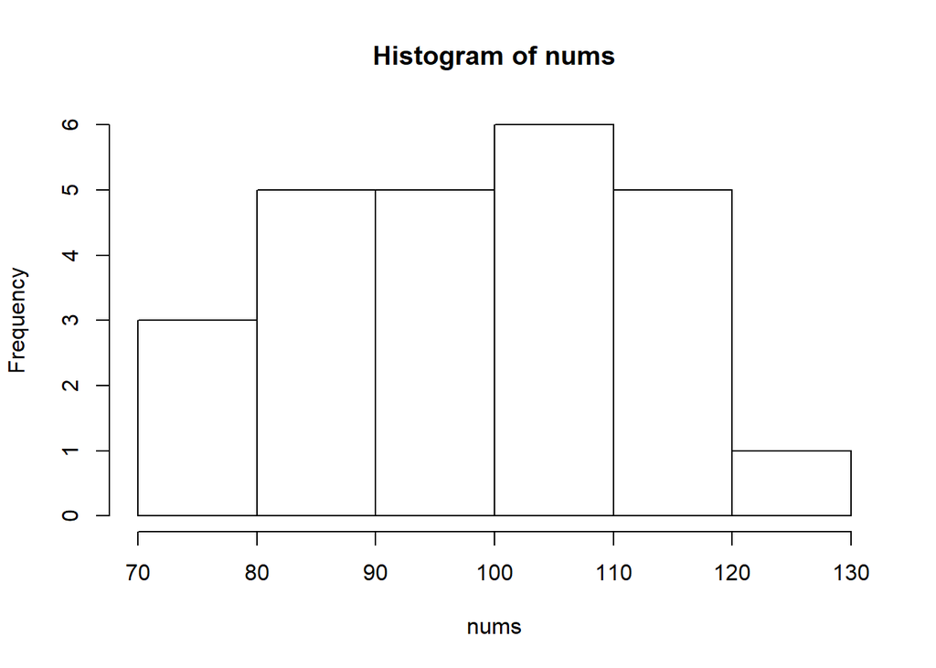

```r
?hist
hist(x = nums)
```

What quantities will we need to calculate the standard error of the mean?

1. The arithmetic mean of the data vector
2. The variance of the data vector
3. The number of elements in the data vector

```r
?stats::var
stats::var(nums)
```

```
## [1] 199.4614
```

```r
?length
length(nums)
```

```
## [1] 25
```

Now that we:

1. Have the components of what we need
2. Understand them
3. Have inspected the output We can proceed.

```r
var.num   <- var(nums)
len.num   <- length(nums)

sem <- sqrt(var.num/len.num)
```

Lets translate the above script into a generic function.

Clear workspace

```r
rm(list = ls())
```

Check environment tab to ensure that there are no lurkingobjects

```r
ls()
```

```
## character(0)
```

Check to make sure that our proposed function name “sem.fun” does not exist

```r
?sem.fun
```

```
## No documentation for 'sem.fun' in specified packages and libraries:
## you could try '??sem.fun'
```

```r
sem.fun = function(x)
{
  var.x <- var(x)
  len.x <- length(x)
sem.val <- sqrt(var.x/len.x)
return(sem.val)
}
```

Lets expand this basic code:

1. How can we make this code robust to missing values?
- How do the length and var functions deal with NA?
- Test them to ensure you know what is being calculated
2. What if we want a histogram returned as well as our calculated values?
3. What if we want to return a multi-element object? (hint: use list in the return function)
- This list will include:
  1. The original data vector
  2. Which if any of the values is/are NA
  3. Which of the values are not NA
  4. The mean of the data vector
4. Save this function with proper and appropriate annotation.

Your first step is to develop a robust script - then translate into a function.

# Parameteric Statistics in R

Last session will be to provide a survey (brief and superificial) of some of the capabilities of base R statistics functionality:

```r
require(stats)
require(datasets)
```

Topics:

1. Measures of position
- Z-scores
- Quantiles
2. Test of the equality of the mean from one or two samples
3. Linear models
- Simple linear regression
- Multiple linear regression
- ANOVA

### Z-scores

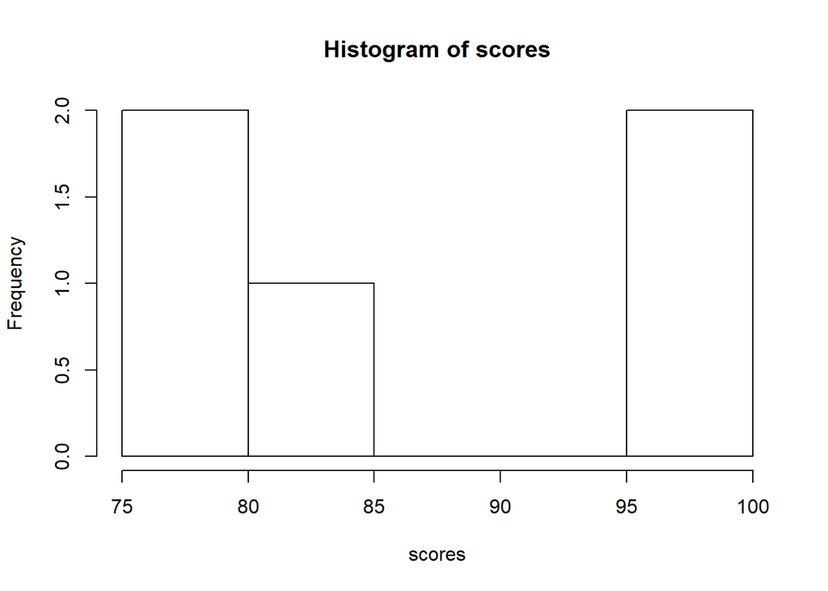

```r
scores <- c(76,80,83,97,100)
?scale
scaled.scores <- scale(scores)
hist(scores)
```

```r
scores.data.frame <- data.frame(scores,scaled.scores)
scores.data.frame
```

```
##   scores scaled.scores
## 1     76    -1.0503591
## 2     80    -0.6752308
## 3     83    -0.3938847
## 4     97     0.9190642
## 5    100     1.2004104
```

```r
plot(x = scores.data.frame$scores,
     y = scores.data.frame$scaled.scores,
     type = "b",
     xlab = "Raw Test Scores",
     ylab = "Scaled Test Scores")
abline(h = 0)
mean(scores)
```

```
## [1] 87.2
```

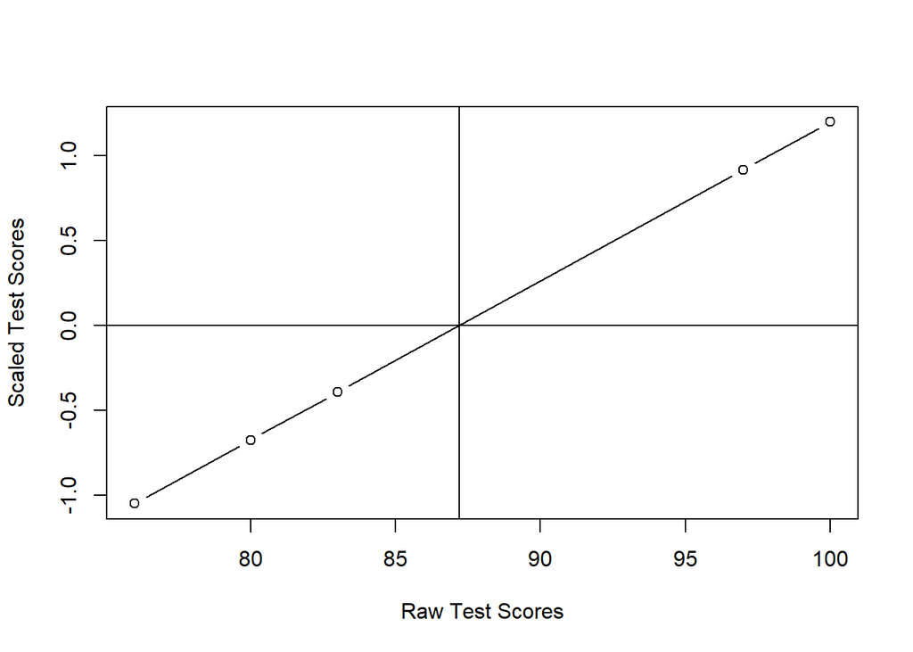

```r
abline(v = mean(scores))
```

```r
z.scores <- c(scores - mean(scores))/sd(scores)
scores.data.frame <- data.frame(scores,scaled.scores,z.scores)
scores.data.frame
```

```
##   scores scaled.scores   z.scores
## 1     76    -1.0503591 -1.0503591
## 2     80    -0.6752308 -0.6752308
## 3     83    -0.3938847 -0.3938847
## 4     97     0.9190642  0.9190642
## 5    100     1.2004104  1.2004104
```

### Quantiles

#### Here is an example using the quantile() function:

The dataset will be using is titled “Nile” and is the flow of the Nile River

```r
?quantile
nile.vect <- as.numeric(Nile)
hist(nile.vect, main = "", xlab = "Nile river discharge volume")
quantile(x = nile.vect)
```

```
##     0%    25%    50%    75%   100%
##  456.0  798.5  893.5 1032.5 1370.0
```

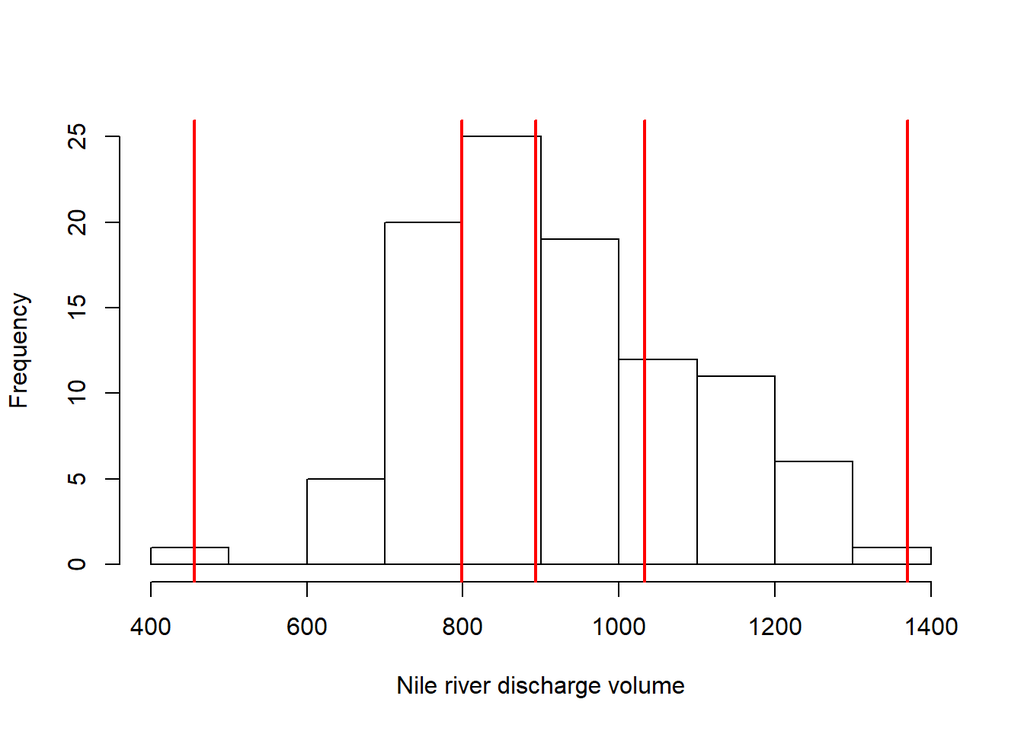

```r
abline(v = quantile(x = nile.vect), col = "red", lwd = 2)
```

### Tests for normality and homogeneity of variance

Shaprio-Wilk test of normality

Null hypothesis - data are normally distributed

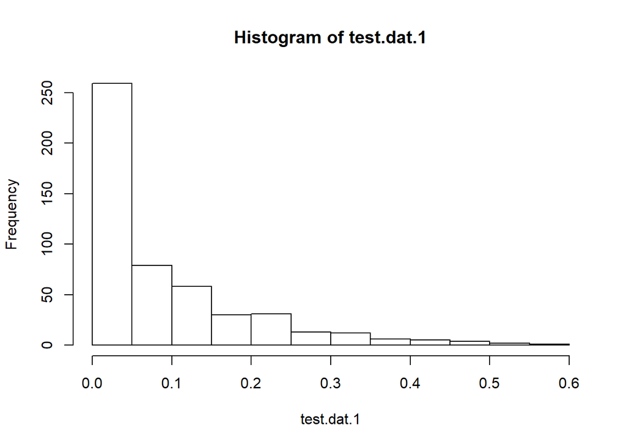

```r
?shapiro.test
?rbeta
test.dat.1 <- rbeta(n = 500, shape1 = 0.5, shape2 = 5)
hist(x = test.dat.1)
```

```r
shapiro.test(x = test.dat.1)
```

```
##
##  Shapiro-Wilk normality test
##
## data:  test.dat.1
## W = 0.79227, p-value < 2.2e-16
```

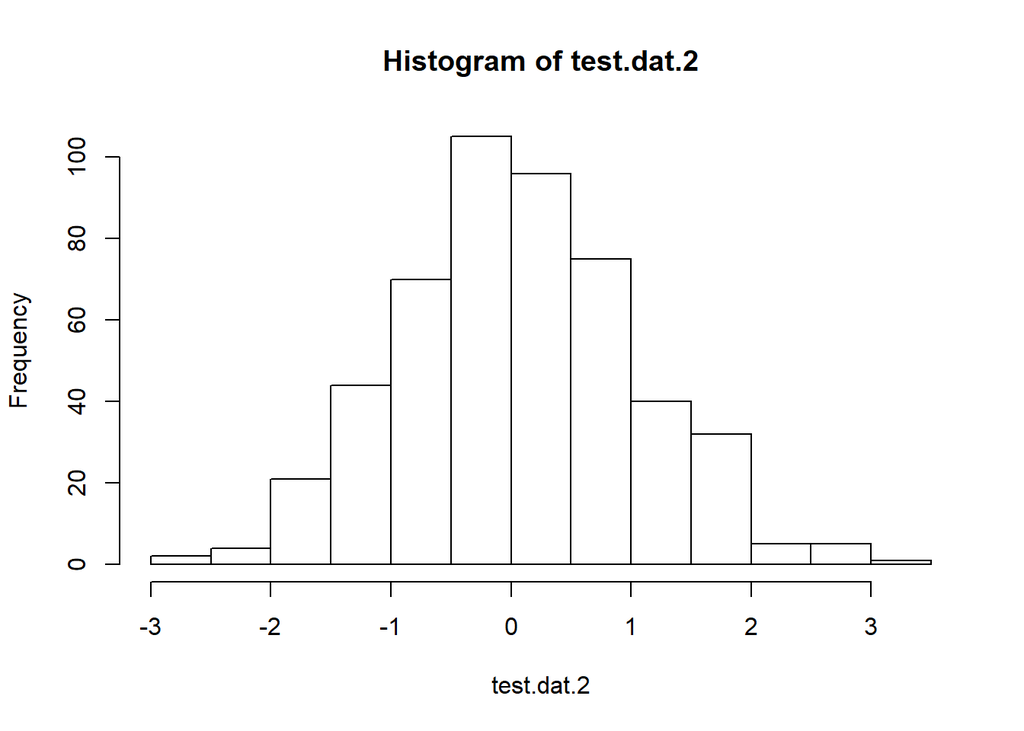

```r
?rnorm
test.dat.2 <- rnorm(n = 500, mean = 0, sd = 1)
hist(x = test.dat.2)
```

```r
shapiro.test(x = test.dat.2)
```

```
##
##  Shapiro-Wilk normality test
##
## data:  test.dat.2
## W = 0.99774, p-value = 0.7457
```

```r
ecol.data <- read.csv("substrate.csv")
head(ecol.data,15)
hist(x = ecol.data$Indicator.A)
```

### Test of the equality of the mean from two samples “t-test”

#### Create vectors from the rexam data.

```r
head(ecol.data)
un.substrate <- unique(ecol.data$Substrate)
un.substrate[1]
un.substrate[2]
ind.1 <- which(ecol.data$Substrate == un.substrate[1])
ind.2 <- which(ecol.data$Substrate == un.substrate[2])

ecol.data$Indicator.A[ind.1]
ecol.data$Indicator.A[ind.2]

t.test(ecol.data$Indicator.A[ind.1], ecol.data$Indicator.A[ind.2])
```

### Creating A Linear Models in R

lm() function can be used to create a simple regression model. The lm() function accepts a number of arguments:

- formula: describes the model
  - This is “YVAR ~ XVAR”
  - YVAR is the dependent (predicted)
  - XVAR is the independent (predictor)

```r
# Load the UNM_Enroll.csv data file
unm.data <- read.csv("UNM_Enroll.csv")
plot(x = unm.data$UNEM,
     y = unm.data$ROLL,
     xlab = "Percent Unemployment",
     ylab = "Enrollment",
     type = "p",
     las = F)

model.object <- unm.data$ROLL ~ unm.data$UNEM
model.object
lm(model.object)
```

- The intercept is 3957 and the coefficient for the unemployment rate is 1134.
- Therefore, the complete regression equation is Fall Enrollment = 3957 + 1134 * Unemployment Rate.
- The predicted fall enrollment for the University of New Mexico will increase by 1134 students for every one percent increase in the unemployment rate.
- Suppose that our research question asks what the expected fall enrollment is, given this year’s unemployment rate of 9%.

```r
plot(x = unm.data$UNEM,
     y = unm.data$ROLL,
     xlab = "Percent Unemployment",
     ylab = "Enrollment",
     type = "p",
     las = F)
abline(v = 9)
```

We can use the regression equation to calculate the answer to this question.

```r
# NHST
anova(lm(model.object))
summary(lm(model.object))
pred.y.vals <- predict(lm(model.object))
plot(x = unm.data$UNEM,
     y = unm.data$ROLL,
     xlab = "Percent Unemployment",
     ylab = "Enrollment",
     type = "p",
     las = F)

lines(x = unm.data$UNEM, pred.y.vals)
```

### Lets increase the complexity of the model:

#### Multiple linear regression

```r
mv.model.object <- unm.data$ROLL ~ unm.data$UNEM + unm.data$HGRAD + unm.data$INC

mv.model.object
lm(mv.model.object)
summary(lm(mv.model.object))
```

### Analysis of Variance

```r
# ANOVAs are linear models with categorical predictors
ecol.data <- read.csv("substrate.csv")
head(ecol.data)
anova.model.object <- ecol.data$Indicator.A ~ ecol.data$Substrate
anova(lm(anova.model.object))
```

### Excercises

- Read in the “hybrid_reg.csv” file
- Make a histogram of the car data characteristic “accelrate”
- Make a histogram of the scaled car data characteristic “accelrate”
- What is the 33 and 66% quantile of msrp for the car data?
- Use a t-test to determine if the mean msrp of “SUV” is significantly greater than the mean msrp of “MV”
- Use a linear model to determine the relationship of msrp as a function of “accelerate” and “mpg”

```r
car.dat <- read.csv("hybrid_reg.csv")
hist(car.dat$accelrate)
hist(scale(car.dat$accelrate))
quantile(car.dat$msrp)
quantile(car.dat$msrp, probs = c(0.33,0.66))

t.test(subset(car.dat$msrp, car.dat$class == "SUV"),
       subset(car.dat$msrp, car.dat$class == "MV"))

lm(msrp ~ accelrate + mpg, data = car.dat)
anova(lm(msrp ~ accelrate + mpg, data = car.dat))
```

# Nonlinear Curve Fitting

R is a great tool for model fitting in general. In this lesson we will use a built in function `nls()` to fit nonlinear models. There are other model fitting functions (e.g `optim()`). The example we will use to demonstrate nonlinear model fitting is the von Bertalanffy growth function (VBGF). The VBGF is ubiquitous in fisheries biology and is a good model to practice with.

We will use the life.histor Rdata file for this exercise.

```r
life.history.dat <- read.csv("fishdata.csv")
```

The first step in any model fitting exercise is to plot the data. In this example we want to plot TL as a function of age.

```r
plot(TL ~  Age, data = life.history.dat) #notice the different way I set up the plot function
```

The version of the VBGF we will be using has two parameters: *Linf* and *k*. *Linf* is the average maximum total length and *k* is the growth rate coefficient. The model equation (without error term) is:

Lt = Linf * (1-e^(-kt))

Lt is the length-at-age age t

###Fitting using nls()

We will use the `nls()` function to execute the model fitting. If you do a `?nls` you will see that `nls()` has several function arguments. Formula is the function form of the model being fit and start is a vector of values to use as initial values for the parameters to be optimized.

```r
model.fit <- nls(TL ~ linf * (1-exp(-k*Age)),
                 start = c(linf = 500, k = 0.2),
                 data = life.history.dat)

# we can use the summary function to look at the summary of our model object.

model.fit.summ <- summary(model.fit)
model.fit.summ

# we can also use the confint() function to get the 95% (or any level) confidence intevals of the parameters

confint(model.fit)
```

It is always a good idea to plot the model to visually analyze the fit to the data. I like using the `curve()` function to accomplish this.

```r
#first, extract the parameter estimates from the model fitting summary (remember indexing!)

linf.est <- model.fit.summ$coefficients[1,1]
k.est <- model.fit.summ$coefficients[2,1]

#use the curve function to plot the curve, use add = T to add it to the same plot.
plot(TL ~  Age, data = life.history.dat)
curve(linf.est * (1-exp(-k.est*x)),
      from = 0, to =  10,
      lwd= 3, add = T)

#visually the model looks good. We could aslo compare models using the AIC() function if we were fitting more than one model to the same data

AIC(model.fit)
```

###Practice

Fit a power model (Weight = a*TL^b) to the weight and length data in the life.history.dat dataset.

```r
#The weight-a-length relationship is W = aL^b

plot(life.history.dat$SL, life.history.dat$WT)

plot(WT ~ TL, data = life.history.dat)

#execute model fitting
w.TL.fit <- nls(WT ~ a * TL^b,
                start = c(a = 0.00001, b = 3),
                data = life.history.dat)

confint(w.TL.fit)
w.TL.summ <- summary(w.TL.fit)
w.TL.summ

a.est <- w.TL.summ$coefficients[1,1]
b.est <- w.TL.summ$coefficients[2,1]

lines(x = seq(200,600),
      y = a.est * seq(200,600)^b.est,
      lwd = 2, col = "blue")
```

###Additional Practice

1. Fit a logistic model the TL at Age data for each sex in life.history.dat TL ~ Linf/(1-e^(-k*Age))

# Principal Component Analysis (PCA)

Last session will be to provide a survey (brief and superificial) of some of the capabilities of base R statistics functionality:

```r
require(utils)
require(stats)
setwd("C:/Users/w906282/Dropbox/Classes/R course")
```

###Create a PCA bi-plot

```r
scian.dat <- utils::read.csv("C:/Users/w906282/Dropbox/Classes/R course/Scianidae Table Data -- Medians.csv")
head(scian.dat)
scian.dat <- scian.dat[which(complete.cases(scian.dat)),]
lab.dat <- scian.dat[,2]
num.dat <- scian.dat[,3:10]
```

```r
SDat_PCA <- stats::princomp(num.dat, cor = TRUE,scores = T, na.action = na.exclude)
summary(SDat_PCA)
loadings(SDat_PCA)  ## note that blank entries are small but not zero
plot(SDat_PCA)
biplot(SDat_PCA)
```